# PYTHON DATA VISUALIZATION WITH MATPLOT_LIB

# Data Visualization?

- Data visualization is the technique to present the data in a pictorial or graphical format. It enables stakeholders and decision makers to analyze data visually. The data in a graphical format allows them to identify new trends and patterns easily. # Why do we need data visualization?
- We need data visualization because a visual summary of information makes it easier to identify patterns and trends than looking through thousands of rows on a spreadsheet. It’s the way the human brain works. Since the purpose of data analysis is to gain insights, data is much more valuable when it is visualized. Even if a data analyst can pull insights from data without visualization, it will be more difficult to communicate the meaning without visualization. Charts and graphs make communicating data findings easier even if you can identify the patterns without them.

# The main benefits of data visualization are as follows:

1. It simplifies the complex quantitative information
2. It helps analyze and explore big data easily
3. It identifies the areas that need attention or improvement

# Three major considerations for Data Visualization:

1. Clarity
2. Accuracy
3. Efficiency
- Clarity- ensures that the data set is complete and relevant. This enables the data scientist to use the new patterns yield from the data in the relevant places.
- Accuracy- ensures using appropriate graphical representation to convey the right message.
- Efficiency- uses efficient visualization technique which highlights all the data points.

# There are some basic factors that one would need to be aware of before visualizing the data.

1. Visual effect
2. Coordination System
3. Data Types and Scale
4. Informative Interpretation
- Visual Effect includes the usage of appropriate shapes, colors, and size to represent the analyzed data.
- The Coordinate System helps to organize the data points within the provided coordinates.
- The Data Types and Scale choose the type of data such as numeric or categorical.
- The Informative Interpretation helps create visuals in an effective and easily interpreted ill manner using labels, title legends, and pointers.

# matplotlib

- matplotlib is a python two-dimensional plotting library for data visualization and creating interactive graphics or plots. Using pythons matplotlib, the data visualization of large and complex data becomes easy.

## matplotlib Advantages

There are several advantages of using matplotlib to visualize data.

- A multi-platform data visualization tool built on the numpy and sidepy framework. Therefore, it's fast and efficient.
- It possesses the ability to work well with many operating systems and graphic backends.
- It possesses high-quality graphics and plots to print and view for a range of graphs such as histograms, bar charts, pie charts, scatter plots and heat maps.
- With Jupyter notebook integration, the developers have been free to spend their time implementing features rather than struggling with compatibility.
- It has large community support and cross-platform support as it is an open source tool.
- It has full control over graph or plot styles such as line properties, thoughts, and access properties.

# Types of Plots

We can create different types of plots using matplotlib:

1. Histogram
2. Scatter Plot
3. Pie Chart
4. Bar chart
5. line chart
6. subplot

# LINE PLOT USING MATPLOTLIB

- A line plot can be difined a a graph that display data as points or check marks above a number line showing the frequency of each values
- A line chart illustrates changes over time. The x-axis is usually a period of time, while the y-axis is quantity. So, this could illustrate a company’s sales for the year broken down by month or how many units a factory produced each day for the past week

```python
#import libarary for Data Visualization
import matplotlib.pyplot as plt
```

```python
#data set
day_city = [1,2,3,4,5,6,7,8,9,10,11,12,13,14,15]
temprature_city =[40,50,60,33,24,45,26,56,45,47,14,25,35,34,26]
```

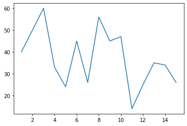

```python
#plot
plt.plot(day_city,temprature_city)
plt.show()
```

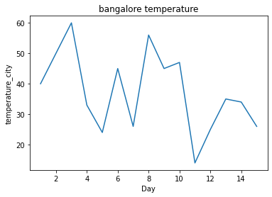

```python
#mention the title ,xlabel and ylabel
plt.plot(day_city,temprature_city)
plt.title("bangalore temperature")
plt.xlabel("Day")
plt.ylabel("temperature_city")
plt.show()
```

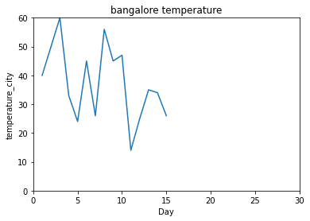

```python
#mention the axis form 0 to end
plt.plot(day_city,temprature_city)
plt.title("bangalore temperature")
plt.xlabel("Day")
plt.ylabel("temperature_city")
plt.axis([0,30, 0,60])
plt.show()
```

# modify the line plot

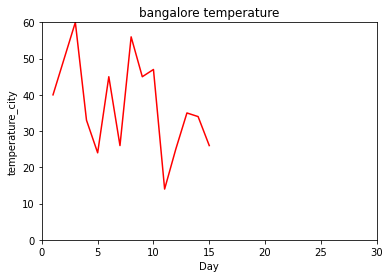

```python
#changed the colors of bar
plt.plot(day_city,temprature_city,color='r')
plt.title("bangalore temperature")
plt.xlabel("Day")
plt.ylabel("temperature_city")
plt.axis([0,30, 0,60])
plt.show()
```

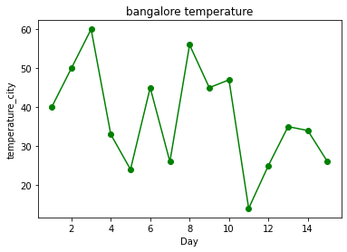

```python
#changed the line format
plt.plot(day_city,temprature_city,color='g',marker='o')
plt.title("bangalore temperature")
plt.xlabel("Day")
plt.ylabel("temperature_city")
plt.show()
```

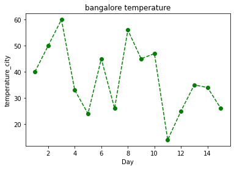

```python
#changed the line style
plt.plot(day_city,temprature_city,color='g',marker='o',linestyle='--')
plt.title("bangalore temperature")
plt.xlabel("Day")
plt.ylabel("temperature_city")
plt.show()
```

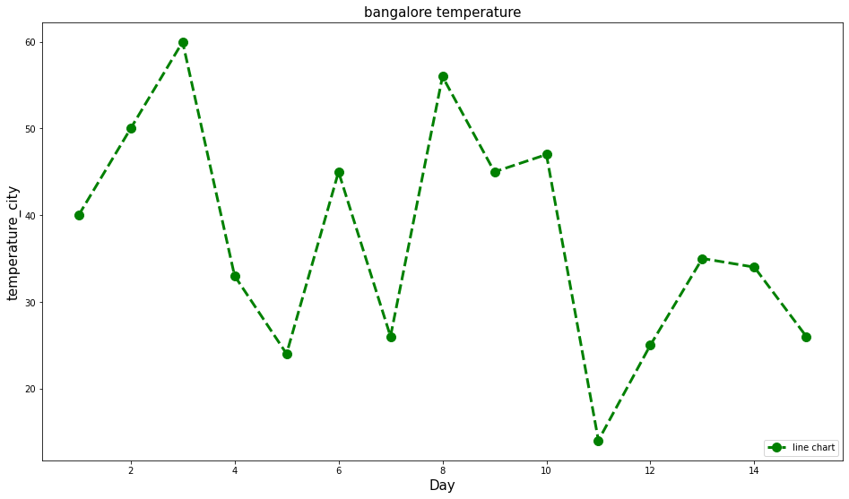

```python
#increase the size of plot, linewidth of line and marker as well as fontsize of title and label
plt.figure(figsize = (16,9))
plt.plot(day_city,temprature_city,color='g',marker='o',linestyle='--',linewidth=3 ,markersize=10,label='line chart')
plt.title("bangalore temperature",fontsize=15)
plt.xlabel("Day",fontsize=15)
plt.ylabel("temperature_city",fontsize=15)
plt.legend(loc = 4)
plt.show()
```

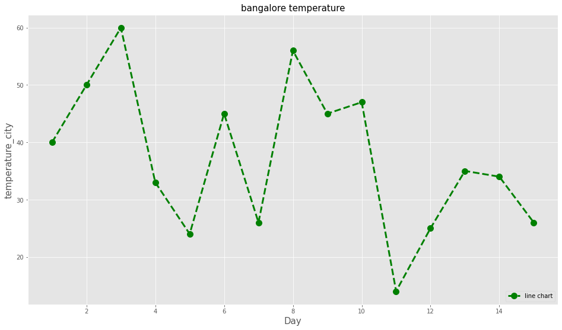

```python
#set background  of the plot
from matplotlib import style
plt.figure(figsize = (16,9))
style.use('ggplot')
plt.plot(day_city,temprature_city,color='g',marker='o',linestyle='--',linewidth=3 ,markersize=10,label='line chart')
plt.title("bangalore temperature",fontsize=15)
plt.xlabel("Day",fontsize=15)
plt.ylabel("temperature_city",fontsize=15)
plt.legend(loc = 4)
plt.show()
```

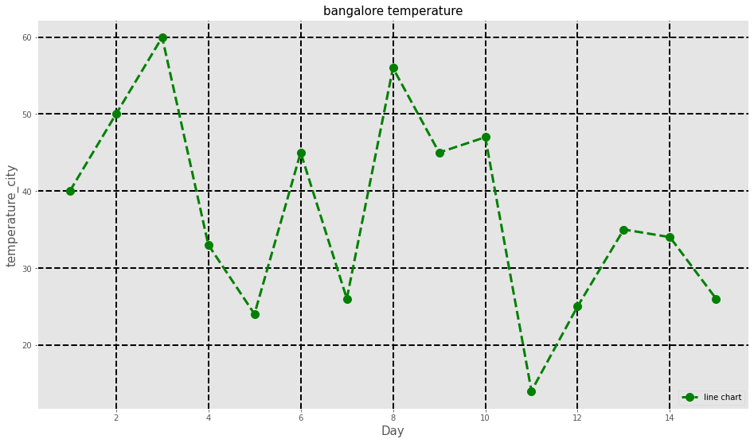

```python
#modify the background grid line
#increage the size of plot, linewidth of line and marker as well as fontsize of title and label
plt.figure(figsize = (16,9))
plt.plot(day_city,temprature_city,color='g',marker='o',linestyle='--',linewidth=3 ,markersize=10,label='line chart')
plt.title("bangalore temperature",fontsize=15)
plt.xlabel("Day",fontsize=15)
plt.ylabel("temperature_city",fontsize=15)
plt.legend(loc = 4)
plt.grid(color='k',linestyle='--',linewidth=2)
plt.show()
```

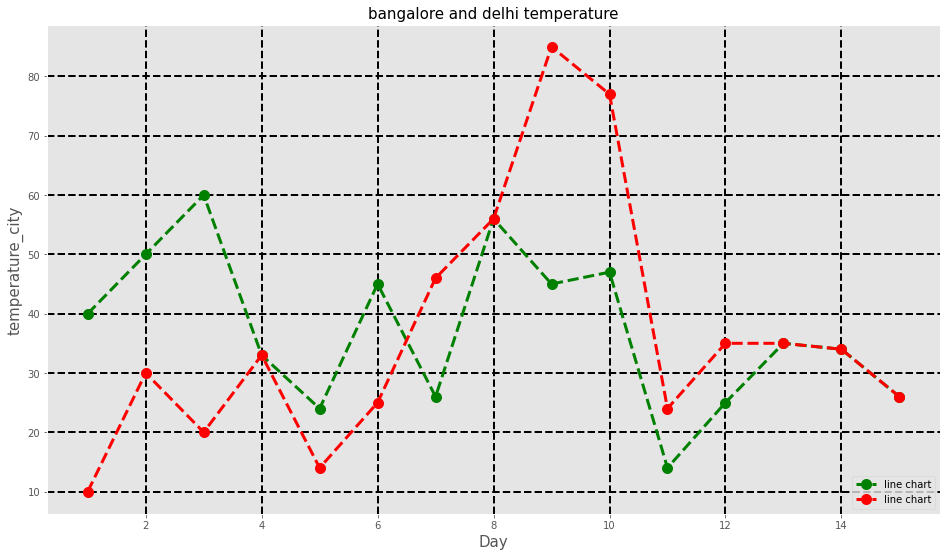

```python
#multiple line chart to show the diffrent city temperature
day_city = [1,2,3,4,5,6,7,8,9,10,11,12,13,14,15]
delhi_city =[40,50,60,33,24,45,26,56,45,47,14,25,35,34,26]
bangalore_city =[10,30,20,33,14,25,46,56,85,77,24,35,35,34,26]
plt.figure(figsize = (16,9))
plt.plot(day_city,delhi_city,color='g',marker='o',linestyle='--',linewidth=3 ,markersize=10,label='line chart')
plt.plot(day_city,bangalore_city,color='r',marker='o',linestyle='--',linewidth=3 ,markersize=10,label='line chart')

plt.title("bangalore and delhi temperature",fontsize=15)
plt.xlabel("Day",fontsize=15)
plt.ylabel("temperature_city",fontsize=15)
plt.legend(loc = 4)
plt.grid(color='k',linestyle='--',linewidth=2)
plt.show()
```

# Histograms

- Histograms are graphical representations of a probability distribution. In Fact, the histogram is a kind of bar chart # WHEN TO USE A HISTOGRAM
1. The data are numerical
2. You want to see the shape of the data’s distribution, especially when determining whether the 3. output of a process is distributed approximately normally
3. Analyzing whether a process can meet the customer’s requirements
4. Analyzing what the output from a supplier’s process looks like
5. Seeing whether a process change has occurred from one time period to another
6. Determining whether the outputs of two or more processes are different
7. You wish to communicate the distribution of data quickly and easily to others # A histogram chart has several advantages.
8. It displays the number of values within a specified interval.
9. It is suitable for large data sets as they can be grouped within the intervals.

```python
import matplotlib.pyplot as plt
import numpy as np
import random
```

```python
ml_student_age = np.random.randint(18,45, (100))
py_student_age = np.random.randint(14,40, (100))
```

```python
print(ml_student_age)
print(py_student_age)
```

```
[39 38 37 44 20 22 36 32 26 33 41 21 26 41 32 18 42 20 34 35 29 44 26 32
 29 33 43 37 36 41 24 31 19 37 22 35 21 27 27 34 36 40 36 18 36 22 33 30
 24 25 36 42 43 31 38 19 37 33 42 43 36 19 41 36 24 43 38 21 29 19 18 34
 19 36 21 44 22 29 21 28 19 22 35 21 34 19 29 34 37 27 44 30 19 32 36 34
 38 36 35 20]
[22 32 32 35 21 39 38 33 31 16 24 24 19 27 16 35 26 15 34 32 31 39 19 29
 31 24 36 28 20 31 20 35 15 35 23 18 30 29 30 15 27 36 33 32 16 18 23 34
 15 39 35 28 33 26 20 20 39 29 20 22 28 23 28 37 19 39 19 15 14 15 37 17
 18 22 30 31 16 23 39 33 37 36 34 17 35 20 23 17 23 34 26 21 16 29 33 29
 35 36 30 33]
```

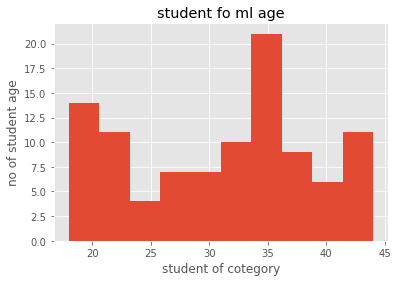

```python
#create a histogram plot
plt.hist(ml_student_age)
plt.title("student fo ml age")
plt.xlabel("student of cotegory")
plt.ylabel("no of student age")
plt.show()
```

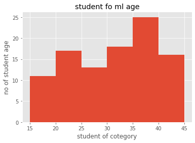

```python
#use bins to categorise the bar particular ways
#create a histogram plot
bins =[15,20,25,30,35,40,45]
plt.hist(ml_student_age,bins)
plt.title("student fo ml age")
plt.xlabel("student of cotegory")
plt.ylabel("no of student age")
plt.show()
```

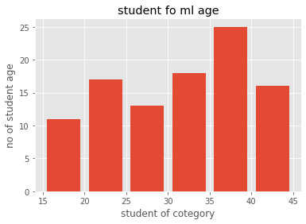

```python
#use bins to categorise the bar particular ways
#see the particular bar
bins =[15,20,25,30,35,40,45]
plt.hist(ml_student_age,bins,rwidth=0.8)
plt.title("student fo ml age")
plt.xlabel("student of cotegory")
plt.ylabel("no of student age")
plt.show()
```

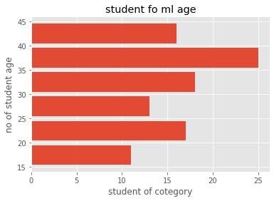

```python
#use bins to categorise the bar particular ways
#see the particular his
#see the char horizontal and type
bins =[15,20,25,30,35,40,45]
plt.hist(ml_student_age,bins,rwidth=0.8,histtype="bar",orientation="horizontal")
plt.title("student fo ml age")
plt.xlabel("student of cotegory")
plt.ylabel("no of student age")
plt.show()
```

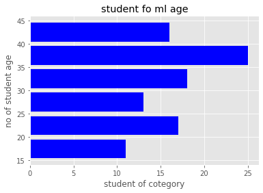

```python
#use bins to categorise the bar particular ways
#see the particular his
#see the char horizontal and type
#change the colors
bins =[15,20,25,30,35,40,45]
plt.hist(ml_student_age,bins,rwidth=0.8,histtype="bar",orientation="horizontal",color='b')
plt.title("student fo ml age")
plt.xlabel("student of cotegory")
plt.ylabel("no of student age")
plt.show()
```

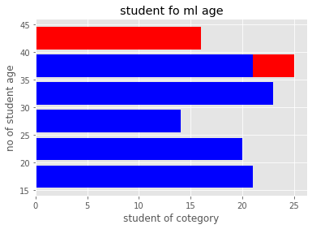

```python
#use bins to categorise the bar particular ways
#see the particular his
#see the char horizontal and type
bins =[15,20,25,30,35,40,45]
plt.hist(ml_student_age,bins,rwidth=0.8,histtype="bar",orientation="horizontal",color='r')
plt.hist(py_student_age,bins,rwidth=0.8,histtype="bar",orientation="horizontal",color='b')

plt.title("student fo ml age")
plt.xlabel("student of cotegory")
plt.ylabel("no of student age")
plt.show()
```

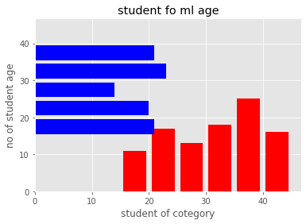

```python
#use bins to categorise the bar particular ways
#see the particular his
#see the char horizontal and type
#multiple graph
bins =[15,20,25,30,35,40,45]
plt.hist(ml_student_age,bins,rwidth=0.8,histtype="bar",orientation="vertical",color='r')
plt.hist(py_student_age,bins,rwidth=0.8,histtype="bar",orientation="horizontal",color='b')

plt.title("student fo ml age")
plt.xlabel("student of cotegory")
plt.ylabel("no of student age")
plt.show()
```

```python
#how to show the own bar
plt.figure(figsize =(16,9))
bins=[15,20,25,30,35,40,45]
plt.hist([ml_student_age,py_student_age], bins, rwidth=0.8 , histtype="bar", orientation='vertical', color=['m','g'] ,label=['ml_student_age','py_student_age'])
#plt.hist(py_student_age, bins, rwidth=0.8 ,histtype="bar",orientation='vertical',color='g' ,label='py_student_age')

plt.title("ml student age histogram")
plt.xlabel("student age category")
plt.ylabel("no student age ")
plt.legend()
plt.show
```

[output not shown]

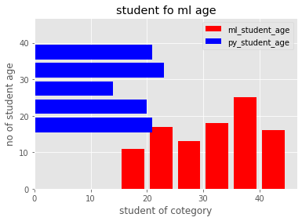

```python
#use bins to categorise the bar particular ways
#see the particular his
#see the char horizontal and type
#see the legend
bins =[15,20,25,30,35,40,45]
plt.hist(ml_student_age,bins,rwidth=0.8,histtype="bar",orientation="vertical",color='r',label='ml_student_age')
plt.hist(py_student_age,bins,rwidth=0.8,histtype="bar",orientation="horizontal",color='b',label='py_student_age')

plt.title("student fo ml age")
plt.xlabel("student of cotegory")
plt.ylabel("no of student age")
plt.legend()
plt.show()
```

# Bar Graph Definition

- The pictorial representation of a grouped data, in the form of vertical or horizontal rectangular bars, where the lengths of the bars are equivalent to the measure of data, are known as bar graphs or bar charts. # Uses of Bar Graphs
- Bar graphs are used to match things between different groups or to trace changes over time. Yet, when trying to estimate change over time, bar graphs are most suitable when the changes are bigger. The types of bar charts are as follows:
1. Vertical bar chart
2. Horizontal bar chart
- Even though the graph can be plotted using horizontally or vertically, the most usual type of bar graph used is the vertical bar graph. The orientation of the x-axis and y-axis are changed depending on the type of vertical and horizontal bar chart. Apart from the vertical and horizontal bar graph, the two different types of bar charts are:
- Grouped Bar Graph
- Stacked Bar Graph

```python
import matplotlib.pyplot as plt
import numpy as np
from matplotlib import style
```

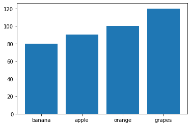

```python
#simple plot
#simple plot
fruits =['banana','apple','orange','grapes']
price=[80,90,100,120]
plt.bar(fruits,price)
plt.show()
```

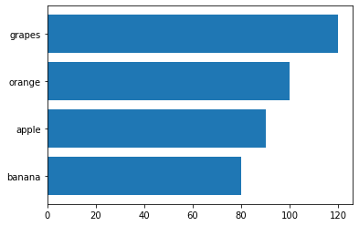

```python
#show  the horizontial bar chart
plt.barh(fruits,price,orientation='horizontal')
plt.show()
```

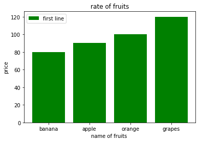

```python
#fill the title color, ylabel ,xlabel ,legend
plt.bar(fruits,price,label ='first line',color='g')
plt.xlabel('name of fruits ')
plt.ylabel('price')
plt.title('rate of fruits')
plt.legend()
plt.show()
```

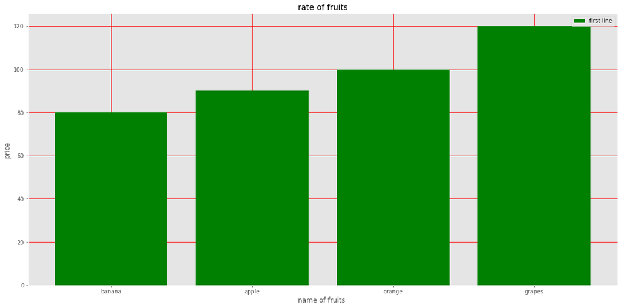

```python
#fill the title color, ylabel ,xlabel ,legend
#show the banground grid and incrage the chart size
style.use('ggplot')
plt.figure(figsize=(19,9))
plt.bar(fruits,price,label ='first line',color='g')
plt.xlabel('name of fruits ')
plt.ylabel('price')
plt.title('rate of fruits')
plt.legend()
plt.grid(True,color='r')
plt.show()
```

[output not shown]

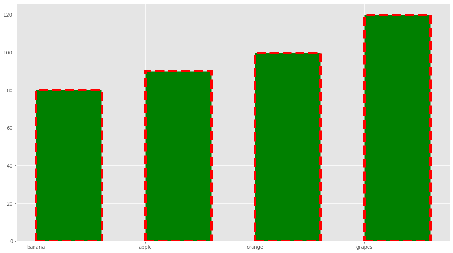

```python
#import the ggplot and put the all method
from matplotlib import style
plt.figure(figsize =(16,9))
style.use("ggplot")
plt.bar(fruits,price,width = 0.6,align ="edge",color='g',edgecolor ='r',
        linewidth =5,linestyle ="--",label ="class 1 student",)
```

# stake bar chart

- A stacked bar chart is a type of bar chart used in excel for the graphical representation of part-to-whole comparison over time. This helps you to represent data in a stacked manner. This type of graph is suitable for data which is represented in different parts and one as a whole. The gradual variation of different variables can be picturized using this.

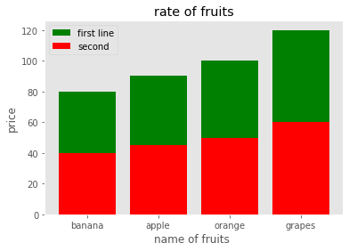

```python
#stake bar char with multiple variable  variable
fruits =['banana','apple','orange','grapes']
price=[80,90,100,120]
less_50 =[40,45,50,60]
plt.bar(fruits,price,label ='first line',color='g')
plt.bar(fruits,less_50,label='second',color='r')
plt.xlabel('name of fruits ')
plt.ylabel('price')
plt.title('rate of fruits')
plt.legend()
plt.grid(False)
plt.show()
```

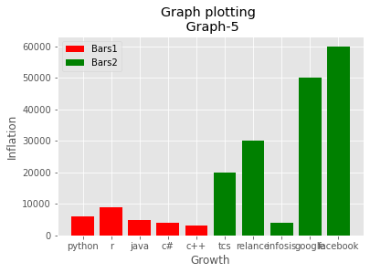

```python
#create a Multi Bar chart with color specification
x = ["python","r","java","c#","c++"]
y = [6000,9000,5000,4000,3000]

x2 = ["tcs","relance","infosis","google","facebook"]
y2 =[20000,30000,4000,50000,60000]
plt.xlabel("Growth")
plt.ylabel("Inflation")
plt.title("Graph plotting \n Graph-5")
plt.bar(x,y, label='Bars1', color ='r')
plt.bar(x2,y2, label='Bars2',color = 'g')
plt.legend()
plt.show()
```

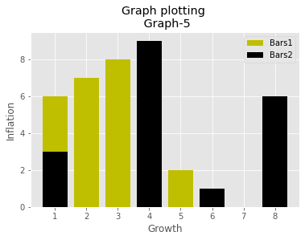

```python
#creating multiple stak bar chart
x = [1,2,3,4,5]
y = [6,7,8,9,2]
x2 = [1,4,6,8,4]
y2 =[3,2,1,6,9]
plt.xlabel("Growth")
plt.ylabel("Inflation")
plt.title("Graph plotting \n Graph-5")
plt.bar(x,y, label='Bars1', color ='y')
plt.bar(x2,y2, label='Bars2',color = 'k')
plt.legend()
plt.show()
```

# Scatter Plots

A scatter plot is used to graphically display the relationship between the variables. A basic plot can be created using the plot method. However, if we need more control of a plot, it's recommended that we use the scatter() method provided by matplotlib. It has several advantages:

1. It shows the correlation between variables
2. It is suitable for large data sets
3. It is easy to find clusters
4. It is possible to represent each piece of data as a point on the plo

```python
#i have taken randon data using numpy
import numpy as np
import random
ml_student_age =np.random.randint(18,45,(100))
py_student_age =np.random.randint(15,40,(100))
```

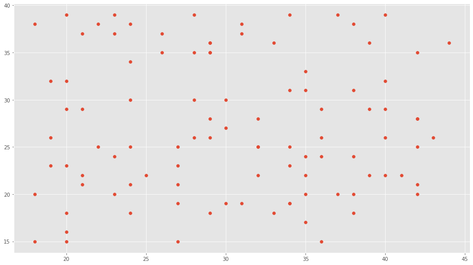

```python
#print the scatter plot
plt.figure(figsize =(16,9))
plt.scatter(ml_student_age,py_student_age)
```

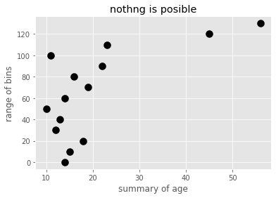

```python
#crete a scatter plot and give the all feature like colurs , size , lab x labe y lab title
population_age=[14,15,18,12,13,10,14,19,16,22,11,23,45,56]
bins =[0,10,20,30,40,50,60,70,80,90,100,110,120,130]
plt.scatter(population_age,bins ,label='skitscat',color='k', s=100)
plt.xlabel('summary of age')
plt.ylabel('range of bins')
plt.title('nothng is posible')
plt.show()
```

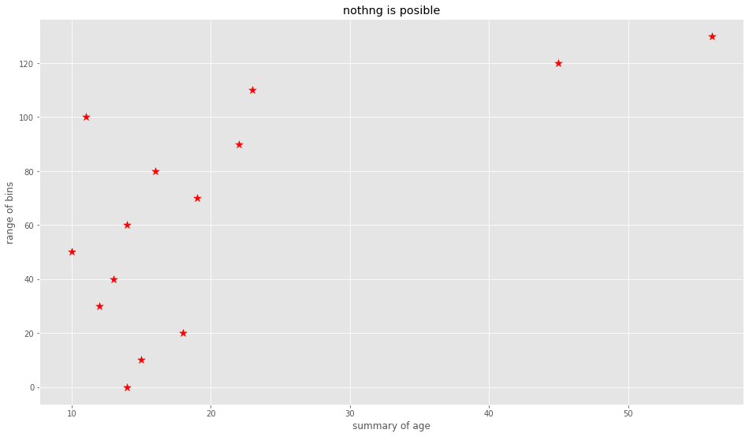

```python
#change the marker of the scatter incrage the size
population_age=[14,15,18,12,13,10,14,19,16,22,11,23,45,56]
bins =[0,10,20,30,40,50,60,70,80,90,100,110,120,130]
plt.figure(figsize=(16,9))
plt.scatter(population_age,bins ,label='skitscat',color='r', s=100, marker='*')
plt.xlabel('summary of age')
plt.ylabel('range of bins')
plt.title('nothng is posible')
plt.show()
```